# Progress Memo 1

Final Project  
Data Science 2 with R (STAT 301-2)

Author

Stacy Caeiro

Published

February 23, 2024

**Github Repo Link**

[Final-Project-GitHub-Link](https://github.com/stat301-2-2024-winter/final-project-2-stacycaeiro.git)

## Prediction Problem

My prediction problem is to predict the amount of social media shares a news article will receive. The target variable is `shares`, which is a numeric variable, so the model will be a regression. I am choosing this problem because increasing social media shares is a common business goal. The results of this model can act as a guide to other publishing sites on how to increase their social media visibility. Additionally, this is a real-world problem I may be faced with when I enter the workforce.

## Data source

For my final project I will be using the [Online News Popularity](https://archive.ics.uci.edu/dataset/332/online+news+popularity) from the [UC Irvine Machine Learning Repository](https://archive.ics.uci.edu/). This dataset contains features of Mashable news articles, such as length of title and date of the week published, that were published over a 2 year period.

## Data quality & complexity check

```
# A tibble: 6 × 61
  url                  timedelta n_tokens_title n_tokens_content n_unique_tokens
  <chr>                    <dbl>          <dbl>            <dbl>           <dbl>
1 http://mashable.com…       731             12              219           0.664
2 http://mashable.com…       731              9              255           0.605
3 http://mashable.com…       731              9              211           0.575
4 http://mashable.com…       731              9              531           0.504
5 http://mashable.com…       731             13             1072           0.416
6 http://mashable.com…       731             10              370           0.560
# ℹ 56 more variables: n_non_stop_words <dbl>, n_non_stop_unique_tokens <dbl>,
#   num_hrefs <dbl>, num_self_hrefs <dbl>, num_imgs <dbl>, num_videos <dbl>,
#   average_token_length <dbl>, num_keywords <dbl>,
#   data_channel_is_lifestyle <dbl>, data_channel_is_entertainment <dbl>,
#   data_channel_is_bus <dbl>, data_channel_is_socmed <dbl>,
#   data_channel_is_tech <dbl>, data_channel_is_world <dbl>, kw_min_min <dbl>,
#   kw_max_min <dbl>, kw_avg_min <dbl>, kw_min_max <dbl>, kw_max_max <dbl>, …
```

## Potential data issues

Although there are 58 predictor variables, due to computer restraints, I may need to downsize the dataset to only include 15-40 variables.

## Target Variable Analysis

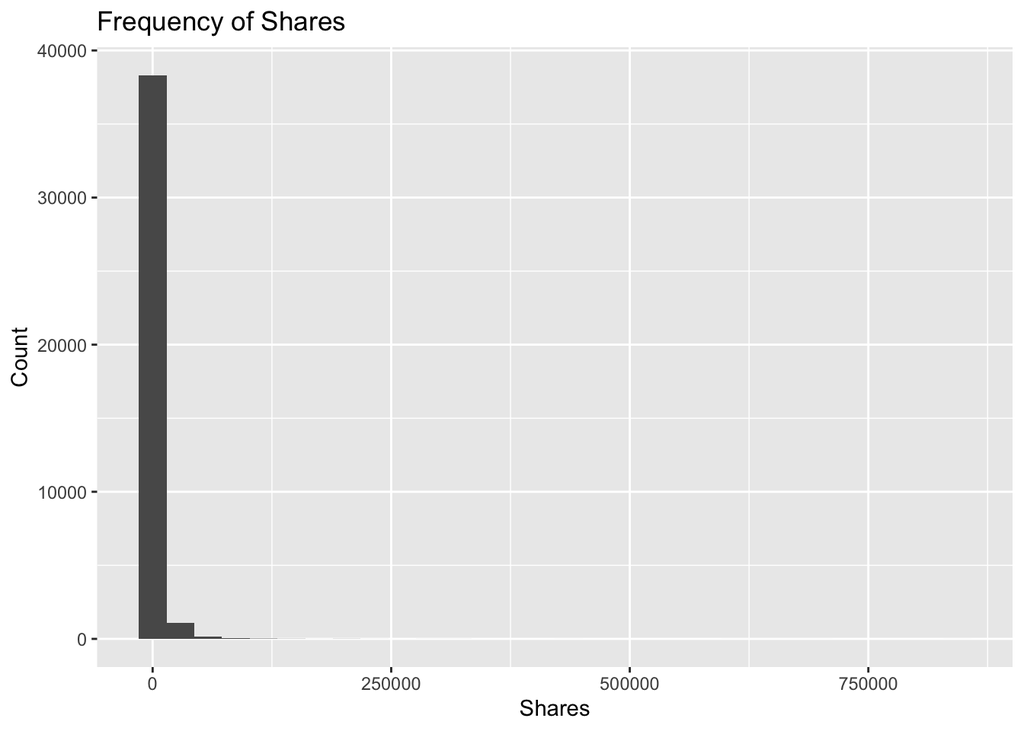

While not immediately apparent in this histogram, there are a few outliers in `shares`, with the max value being 843,300 shares.

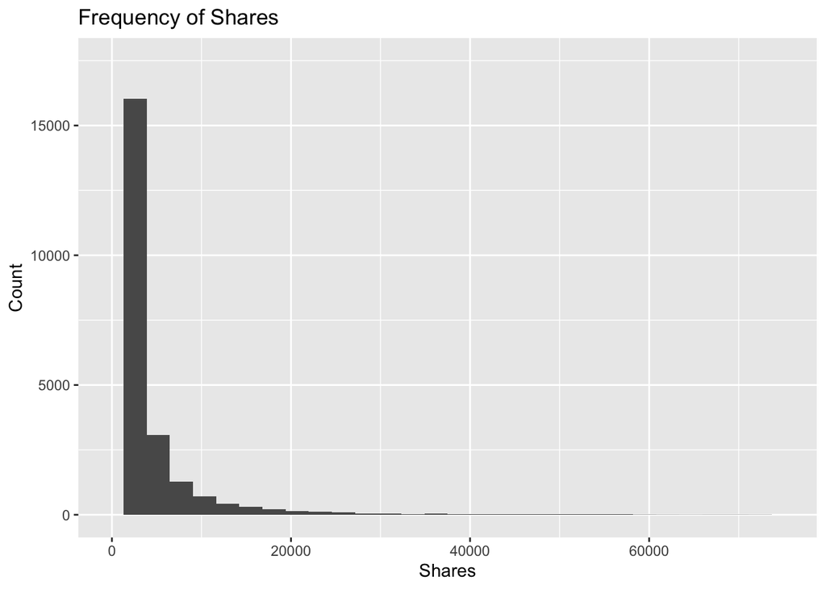

Upon zooming into the histogram, `shares` is right-skewed, as fewer amounts of articles receive high amounts of shares. In fact, most articles only recieve around 10,000 or less shares.